# Create Place Population File

Author

Aaron R. Williams

Published

November 24, 2025

Abstract

```r
library(tidyverse)
library(tidycensus)
library(assertr)
library(here)
library(urbnthemes)

set_urbn_defaults("print")
options(scipen = 999)
```

```r
number_of_years <- 12
```

## 2014 & 2015-2019

```r
#' Get population estimates from the US Census Bureau Population Estimation Program
#'
#' @param year An integer for the year of interest
#'
#' @return A data frame with estimate for all US counties
#'
get_pop <- function(year) {
  pop <- tidycensus::get_estimates("place", year = year, variables = "POP") %>%
    mutate(year = year)

  return(pop)
}


# pull county population data for each year from the Population Estimates Program
# API only works from 2015 to 2019, 2014 pulled in manually
pep_2015_2019 <- map_dfr(
  .x = 2015:2019,
  .f = ~ get_pop(year = .x)
)
```

## 2020

```r
# pull the 2020 decennial census
census2020 <- get_decennial(
  geography = "place",
  year = 2020,
  variables = "P1_001N",
  keep_geo_vars = TRUE
) |>
  select(NAME, GEOID, variable, value) |>
  mutate(year = 2020)
```

## Combine

We combine the PEP data and decennial census data

```r
pop <- bind_rows(pep_2015_2019, census2020)

# drop unnecessary variable and rename the useful variable
pop <- pop %>%
  select(-variable) %>%
  rename(
    population = value,
    place_state_name = NAME,
    state_place = GEOID
  )

pop <- pop |>
  separate(place_state_name, into = c("place_name", "state_name", "c", "d", "e"), sep = ",") |>
  mutate(
    state_name = str_squish(state_name),
    place_name = str_squish(place_name)
  ) |>
  mutate(
    state = str_sub(state_place, start = 1, end = 2),
    place = str_sub(state_place, start = 3, end = 7)
  ) |>
  select(year, state, place, state_name, place_name, population) %>%
  arrange(year, state, place)
```

## 2021-2024

```r
# Specify URL where source data file is online
placeurl <-
  "https://www2.census.gov/programs-surveys/popest/datasets/2020-2024/cities/totals/sub-est2024.csv"

# Specify destination where file should be saved (the .gitignore folder for your local branch)
destfileplace <- here("geographic-crosswalks", "data", "raw", "sub-est2024.csv")

# Import the data file & save locally
if (!file.exists(destfileplace)) {
  download.file(placeurl, destfileplace, mode = "wb")
}

pep_2021_2024 <- read_csv(destfileplace) %>%
  rename_with(tolower) %>%
  # Convert state to character and add a leading zero
  mutate(
    state = str_pad(state, width = 2, pad = "0"),
    place = str_pad(place, width = 2, pad = "0")
  ) %>%
  mutate(across(c(state, place), as.character)) %>%
  filter(sumlev == 162) %>%
  select(
    state, place,
    state_name = stname,
    place_name = name,
    starts_with("popestimate")
  ) %>%
  # remove unnecessary data before reshaping
  filter(place != "00000") %>%
  # reshape by place
  pivot_longer(
    cols = starts_with("popestimate"),
    names_to = "year",
    values_to = "population"
  ) %>%
  mutate(
    year = as.numeric(str_remove(string = year, pattern = "popestimate")),
  ) %>%
  filter(year > 2020)
```

The PEP file includes disaggregations of places and duplicate places. We drop these.

```r
pep_2021_2024 <- pep_2021_2024 |>
  filter(!str_detect(place_name, pattern = "(pt\\.)")) |>
  distinct(year, state, place, state_name, place_name, population)
```

## 2014

```r
# Specify URL where source data file is online
placeurl14 <-
  "https://www2.census.gov/programs-surveys/popest/datasets/2010-2014/cities/totals/sub-est2014_all.csv"

# Specify destination where file should be saved (the .gitignore folder for your local branch)
destfileplace14 <- here("geographic-crosswalks", "data", "raw", "sub-est2014.csv")

# Import the data file & save locally
if (!file.exists(destfileplace14)) {
  download.file(placeurl14, destfileplace14, mode = "wb")
}

pep_2014 <- read_csv(destfileplace14) %>%
  rename_with(tolower) %>%
  # Convert state to character and add a leading zero
  mutate(
    state = str_pad(state, width = 2, pad = "0"),
    place = str_pad(place, width = 5, pad = "0")
  ) %>%
  mutate(across(c(state, place), as.character)) %>%
  filter(sumlev == 162) |>
  select(
    state, place,
    state_name = stname,
    place_name = name,
    starts_with("popestimate")
  ) %>%
  # remove unnecessary data before reshaping
  filter(place != "00000") %>%
  # reshape by place
  pivot_longer(
    cols = starts_with("popestimate"),
    names_to = "year",
    values_to = "population"
  ) %>%
  mutate(
    year = as.numeric(str_remove(string = year, pattern = "popestimate")),
  ) %>%
  filter(year > 2013)
```

The PEP file includes disaggregations of places and duplicate places. We drop these.

```r
pep_2014 <- pep_2014 %>%
  filter(!str_detect(place_name, pattern = "(pt\\.)")) %>%
  distinct(year, state, place, state_name, place_name, population)
```

## 2025

```r
pep_2025 <- pep_2021_2024 |>
  filter(year == 2024) |>
  mutate(year = 2025) |>
  select(-population)
```

## Combine Data

```r
final_population <- bind_rows(
  pep_2014,
  pop,
  pep_2021_2024,
  pep_2025
)

final_population <- final_population |>
  arrange(year, state, place, state_name, place_name) |>
  mutate(in_universe = TRUE)
```

## Subset Data

We are only interested in incorporated places with more than 75,000 people in 2020. We use a specific file from PEP to create a list of 486 FIPS of interest.

```r
# Specify URL where source data file is online
placeurl <-
  "https://www2.census.gov/programs-surveys/popest/datasets/2020-2022/cities/totals/sub-est2022.csv"

# Specify destination where file should be saved (the .gitignore folder for your local branch)
destfileplace <- here("geographic-crosswalks", "data", "raw", "sub-est2022.csv")

# Import the data file & save locally
if (!file.exists(destfileplace)) {
  download.file(placeurl, destfileplace, mode = "wb")
}

pep_2022 <- read_csv(here("geographic-crosswalks/data/raw/sub-est2022.csv")) |>
  mutate(state_place = paste0(STATE, PLACE))

my_places <- pep_2022 |>
  filter(POPESTIMATE2020 > 75000, SUMLEV == "162") |>
  pull(state_place)

final_population <- final_population |>
  filter(paste0(state, place) %in% my_places)
```

**Check:** Are there places on the cutoff of our population threshold?

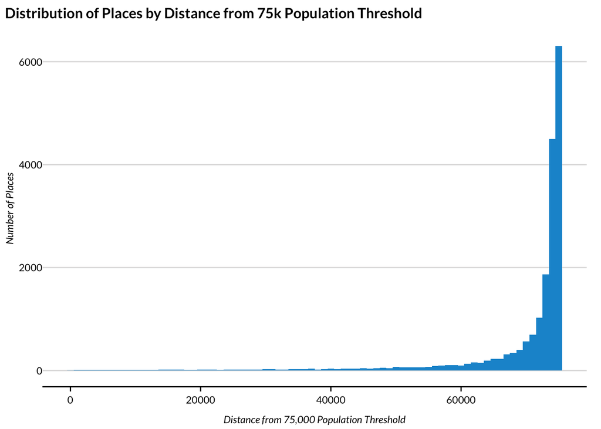

```r
# Plotting Population for All Places with Threshold Line
places_near_threshold <-
  pep_2022 |>
  filter(SUMLEV == "162") |>
  mutate(
    distance_from_threshold = if_else(POPESTIMATE2020 < 75 * 1e3,
      75 * 1e3 - POPESTIMATE2020,
      0
    )
  ) |>
  filter(distance_from_threshold > 0) |>
  # filter(between(distance_from_threshold, 1, 10*1e3)) |>
  select(state_place, POPESTIMATE2020, distance_from_threshold)

ggplot(places_near_threshold, aes(x = distance_from_threshold)) +
  geom_histogram(binwidth = 1000) +
  labs(
    title = "Distribution of Places by Distance from 75k Population Threshold",
    x = "Distance from 75,000 Population Threshold",
    y = "Number of Places"
  )
```

Zooming in on places that are 10,000 below our cut-off

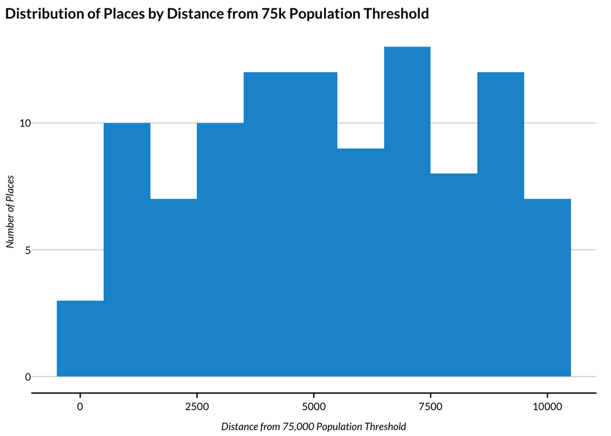

```r
places_near_threshold |>
  filter(between(distance_from_threshold, 1, 10 * 1e3)) |>
  ggplot(aes(x = distance_from_threshold)) +
  geom_histogram(binwidth = 1000) +
  labs(
    title = "Distribution of Places by Distance from 75k Population Threshold",
    x = "Distance from 75,000 Population Threshold",
    y = "Number of Places"
  )
```

There are 103 places that are within 10,000 of our 75,000 population threshold.

## Evaluation

```r
final_population |>
  count(year) |>
  assert(
    in_set(485, 486),
    n
  )
```

```
# A tibble: 12 × 2
    year     n
   <dbl> <int>
 1  2014   485
 2  2015   485
 3  2016   485
 4  2017   485
 5  2018   486
 6  2019   486
 7  2020   486
 8  2021   486
 9  2022   486
10  2023   486
11  2024   486
12  2025   486
```

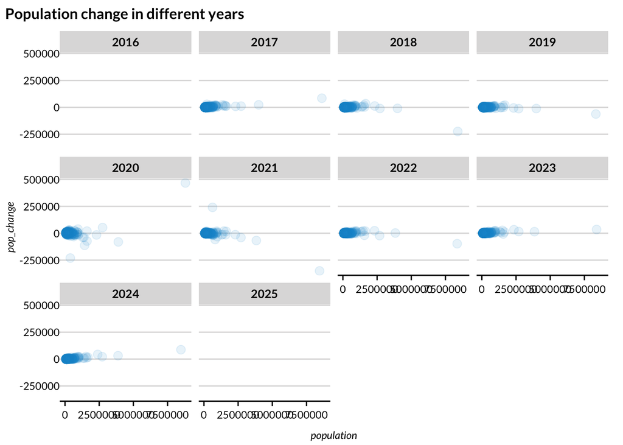

```r
population_test <- final_population |>
  filter(year > 2015) |>
  group_by(state, place) |>
  mutate(
    pop_change = population - lag(population),
    prop_pop_change = (population - lag(population)) / lag(population)
  ) |>
  ungroup()

population_test |>
  ggplot(aes(population, pop_change)) +
  geom_point(alpha = 0.1) +
  facet_wrap(~year) +
  labs(title = "Population change in different years")
```

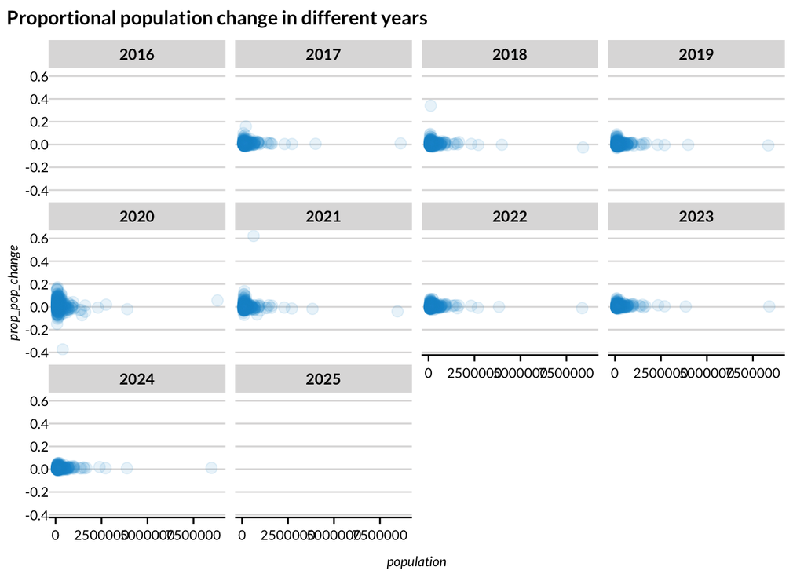

```r
population_test |>
  ggplot(aes(population, prop_pop_change)) +
  geom_point(alpha = 0.1) +
  facet_wrap(~year) +
  labs(title = "Proportional population change in different years")
```

We can look at the places with the largest proportion change.

```r
population_test |>
  slice_max(abs(prop_pop_change), n = 30) |>
  print(n = Inf)
```

```
# A tibble: 30 × 9
    year state place state_name    place_name  population in_universe pop_change
   <dbl> <chr> <chr> <chr>         <chr>            <dbl> <lgl>            <dbl>
 1  2021 21    48006 Kentucky      Louisville…     627376 TRUE            240492
 2  2020 21    48006 Kentucky      Louisville…     386884 TRUE           -230754
 3  2018 48    70808 Texas         Sugar Land…     118600 TRUE             30115
 4  2020 26    21000 Michigan      Dearborn c…     109976 TRUE             16044
 5  2020 12    32275 Florida       Homestead …      80737 TRUE             11214
 6  2017 06    69088 California    Santa Clar…     210888 TRUE             28916
 7  2020 12    17935 Florida       Doral city       75874 TRUE             10133
 8  2020 26    29000 Michigan      Flint city       81252 TRUE            -14286
 9  2020 04    07940 Arizona       Buckeye ci…      91502 TRUE             11882
10  2020 01    03076 Alabama       Auburn city      76143 TRUE              9884
11  2021 48    42508 Texas         Lewisville…     127253 TRUE             15431
12  2020 34    36000 New Jersey    Jersey Cit…     292449 TRUE             30374
```

[output cut: 19 more lines]

We can look at places with the largest absolute change in population.

```r
population_test |>
  slice_max(abs(pop_change), n = 30) |>
  print(n = Inf)
```

```
# A tibble: 30 × 9
    year state place state_name place_name     population in_universe pop_change
   <dbl> <chr> <chr> <chr>      <chr>               <dbl> <lgl>            <dbl>
 1  2020 36    51000 New York   New York city     8804190 TRUE            467373
 2  2021 36    51000 New York   New York city     8453772 TRUE           -350418
 3  2021 21    48006 Kentucky   Louisville/Je…     627376 TRUE            240492
 4  2020 21    48006 Kentucky   Louisville/Je…     386884 TRUE           -230754
 5  2018 36    51000 New York   New York city     8398748 TRUE           -223950
 6  2020 48    65000 Texas      San Antonio c…    1434625 TRUE           -112628
 7  2022 36    51000 New York   New York city     8356179 TRUE            -97593
 8  2024 36    51000 New York   New York city     8478072 TRUE             87184
 9  2017 36    51000 New York   New York city     8622698 TRUE             85025
10  2020 06    44000 California Los Angeles c…    3898747 TRUE            -80829
11  2020 04    55000 Arizona    Phoenix city      1608139 TRUE            -72853
12  2021 06    44000 California Los Angeles c…    3830987 TRUE            -67760
```

[output cut: 19 more lines]

We can look at places with FIPS that don’t show up in every year.

```r
final_population |>
  group_by(state, place) |>
  mutate(fips_frequency = n()) |>
  filter(fips_frequency != number_of_years) |>
  ungroup() |>
  distinct(state, place, state_name, place_name) |>
  print(n = Inf)
```

```
# A tibble: 1 × 4
  state place state_name place_name
  <chr> <chr> <chr>      <chr>
1 13    72122 Georgia    South Fulton city
```

We can look at places with place names that don’t show up in every year.

```r
final_population |>
  group_by(state_name, place_name) |>
  mutate(fips_frequency = n()) |>
  filter(fips_frequency != number_of_years) |>
  ungroup() |>
  distinct(state, place, state_name, place_name) |>
  print(n = Inf)
```

```
# A tibble: 5 × 4
  state place state_name place_name
  <chr> <chr> <chr>      <chr>
1 04    07940 Arizona    Buckeye town
2 18    23278 Indiana    Fishers town
3 04    07940 Arizona    Buckeye city
4 18    23278 Indiana    Fishers city
5 13    72122 Georgia    South Fulton city
```

## Save Data

The PEP data are reported using the geographies at the time the estimates were generated. This means the 2024 data include Connecticut’s planning regions in 2021 even though they didn’t exist at that point. Accordingly, we will download earlier data.

```r
# We have 486 cities from 2018-2024, so for 7 years we should have 2916 observations.
# South Fulton city, Georgia was incorporated in 2017, so we only
# have population estimates for this city from 2018-2024. Therefore, from 2014-2017,
# for 4 years we should have 485 observations for each, or 1940 total.
# Overall, should have 2916+1940, which is why we have 4856 total observations

write_csv(
  x = final_population,
  file = here::here("geographic-crosswalks/data/place-populations.csv")
)
```